# ¿Quién sobrevivió al Titanic?

Autores/as

Gema Fernández-Avilés (Gema.FAviles@uclm.es)

Isidro Hidalgo (Isidro.Hidalgo@uclm.es)

Fecha de publicación

16 de enero de 2025

**Nota**

Los datos para esta historia están sacados de la competición de kaggle “Titanic - Machine Learning from Disaster”: https://www.kaggle.com/competitions/titanic. Los datasets de entrenamiento y test se encuentran en el objeto `titanic` del paquete `titanic`.

**Instalación y/o carga del paquete `titanic`**

```r
if (!require(titanic)){install.packedads("titanic")}
```

# 1 ¿Quién sobrevivió al Titanic?

Mi colega de departamento se ha picado con el departamento vecino, y se han apostado que ganaban el próximo datathon de GAIA-X. No pasaría nada, sería su problema, si no me hubiera pedido que le ayudara con el análisis exploratorio, que está mal de tiempo… lo de siempre… ¡¿Pero por qué no pueden dejarme tranquilo?!

# 2 Entender el contexto

**Cómo definir el propósito y la audiencia de tu análisis**

En este caso, puesto que el objetivo de mi colega es la predicción, lo primero que vamos a hacer es un análisis exploratorio, para ver las relaciones entre las variables del conjunto de datos. Luego ya se apañará mi compañero para modelizar… ¡a ver si se piensa que lo voy a hacer todo yo!

**Configuración inicial y datos**

```r
library(titanic)
library(tidyverse)
library(skimr)
library(explore)
library(caret)
library(ggmosaic)
library(ggalluvial)
library(pROC)
library(visdat)

titanic <- titanic_train
names(titanic)[1:6] <- c("id", "supervivencia", "clase", "nombre", "sexo", "edad")
head(titanic)
```

```
  id supervivencia clase                                              nombre
1  1             0     3                             Braund, Mr. Owen Harris
2  2             1     1 Cumings, Mrs. John Bradley (Florence Briggs Thayer)
3  3             1     3                              Heikkinen, Miss. Laina
4  4             1     1        Futrelle, Mrs. Jacques Heath (Lily May Peel)
5  5             0     3                            Allen, Mr. William Henry
6  6             0     3                                    Moran, Mr. James
    sexo edad SibSp Parch           Ticket    Fare Cabin Embarked
1   male   22     1     0        A/5 21171  7.2500              S
2 female   38     1     0         PC 17599 71.2833   C85        C
3 female   26     0     0 STON/O2. 3101282  7.9250              S
4 female   35     1     0           113803 53.1000  C123        S
5   male   35     0     0           373450  8.0500              S
6   male   NA     0     0           330877  8.4583              Q
```

**Exploramos variables del dataset de entrenamiento**

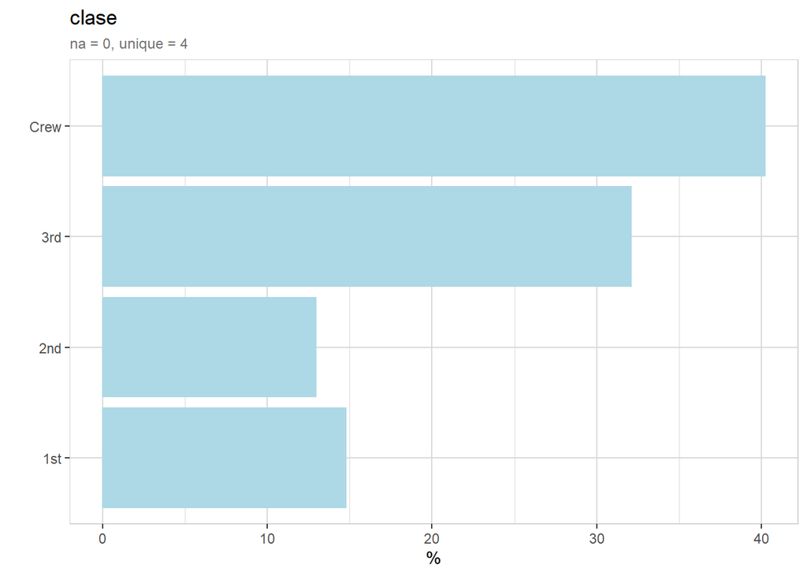

```r
titanic_conteo <- use_data_titanic(count = TRUE) # más adelante no contaremos por variables, porque nos interesarán los datos "crudos"
names(titanic_conteo) <- c("clase", "sexo", "edad", "supervivencia", "n")
titanic_conteo |> explore(clase, n = n)
```

**Exploramos variables del dataset de entrenamiento**

```r
titanic_conteo |> describe(clase, n = n)
```

```
variable = clase
type     = character
na       = 0 of 2 201 (0%)
unique   = 4
 1st     = 325 (14.8%)
 2nd     = 285 (12.9%)
 3rd     = 706 (32.1%)
 Crew    = 885 (40.2%)
```

**Exploramos variables del dataset de entrenamiento**

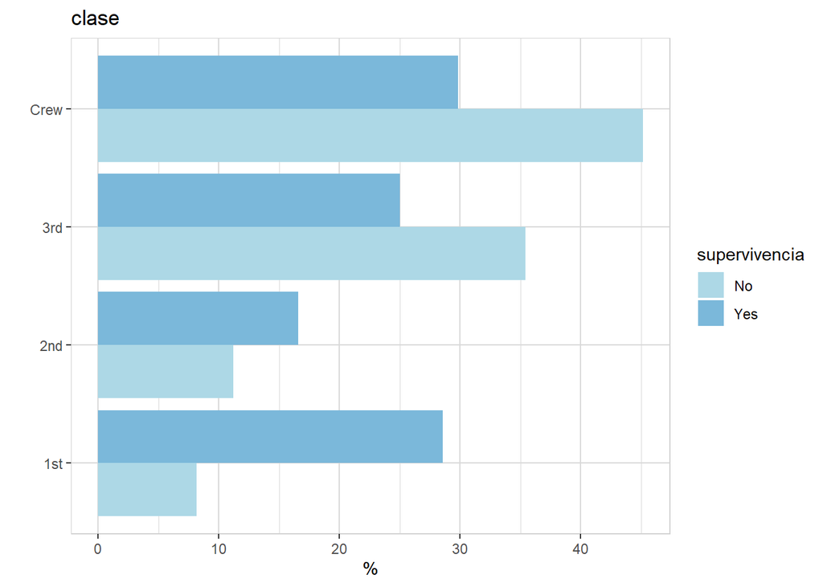

```r
# ¿Cuántos sobrevivieron de cada clase?:
titanic_conteo |> explore(clase,
                          target = supervivencia,
                          n = n, split = TRUE)
```

**También podemos explorar todas las variables del dataset de una forma más resumida**

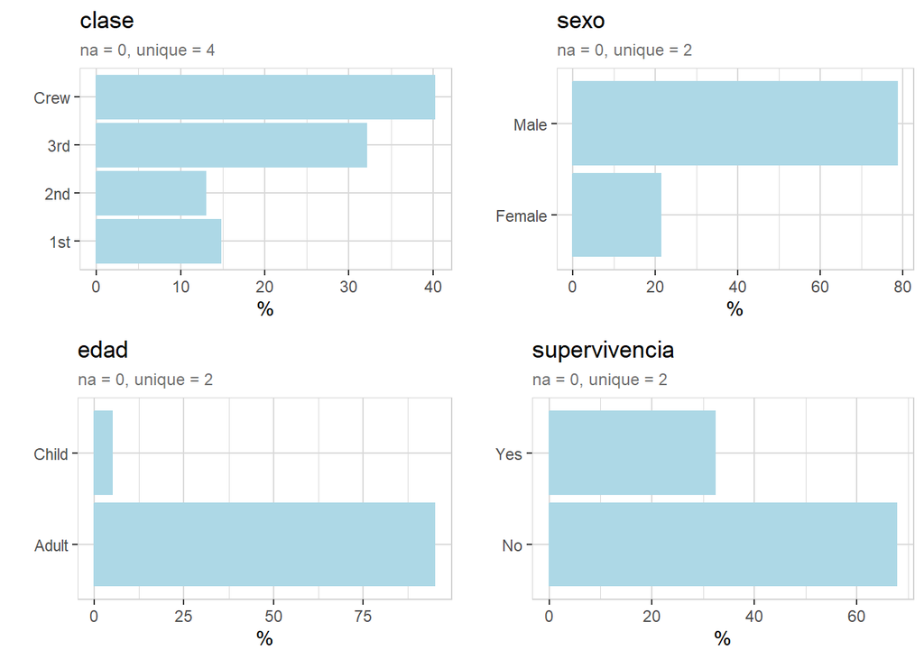

```r
titanic_conteo |> explore_all(n = n)
```

**skimr es un paquete que conviene memorizar**

```r
skim(titanic_conteo)
```

Data summary

| Name | titanic_conteo |
| --- | --- |
| Number of rows | 32 |
| Number of columns | 5 |
| _______________________ |  |
| Column type frequency: |  |
| character | 4 |
| numeric | 1 |
| ________________________ |  |
| Group variables | None |

**Variable type: character**

| skim_variable | n_missing | complete_rate | min | max | empty | n_unique | whitespace |
| --- | --- | --- | --- | --- | --- | --- | --- |
| clase | 0 | 1 | 3 | 4 | 0 | 4 | 0 |
| sexo | 0 | 1 | 4 | 6 | 0 | 2 | 0 |
| edad | 0 | 1 | 5 | 5 | 0 | 2 | 0 |
| supervivencia | 0 | 1 | 2 | 3 | 0 | 2 | 0 |

**Variable type: numeric**

| skim_variable | n_missing | complete_rate | mean | sd | p0 | p25 | p50 | p75 | p100 | hist |
| --- | --- | --- | --- | --- | --- | --- | --- | --- | --- | --- |
| n | 0 | 1 | 68.78 | 136 | 0 | 0.75 | 13.5 | 77 | 670 | ▇▁▁▁▁ |

# 3 Elegir una visualización adecuada

**Selección de gráficos y visualizaciones que mejor representen tus datos.**

## 3.1 ¿Hombre o mujer?

Hemos visto como se relaciona la supervivencia con la pertenencia a la tripulación o a una clase en concreto, pero ¿influyó el sexo?

Si usamos un diagrama de mosaico, que es un método gráfico para visualizar datos de dos o más variables cualitativas, podemos tener una visión general de los datos y reconocer relaciones entre diferentes variables cualitativas.

Veamos la `supervivencia` de los pasajeros del Titanic en función del `sexo` (ambas variables cualitativas).

**Tu turno**

Completa las partes del código señaladas por `_____` o `xxxxx` para obtener el resultado propuesto.

**Código**

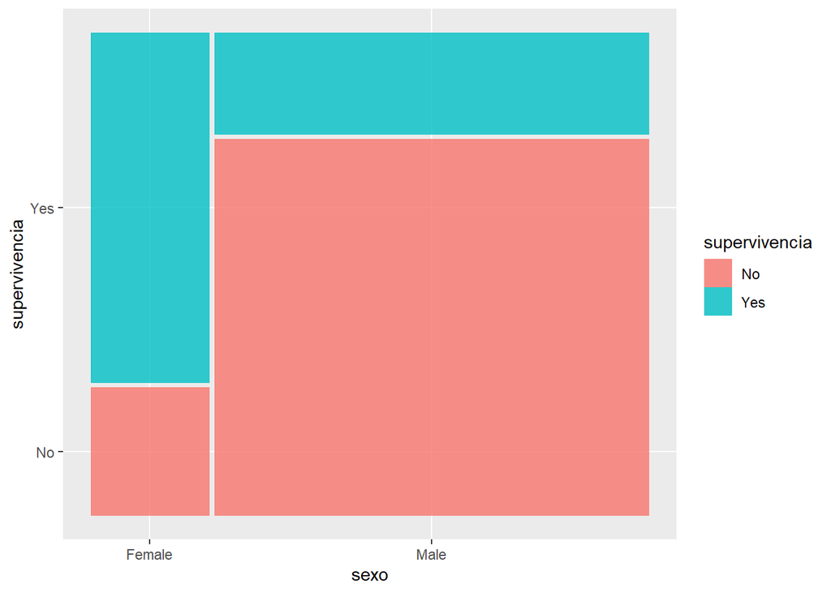

```r
titanic <- use_data_titanic(count = _____) # ahora trabajamos con los datos "crudos"
names(titanic) <- c("clase", "sexo", "edad", "supervivencia")

mosaico2 <- ggplot(data = titanic) +
  geom_xxxxxx(aes(x = product(supervivencia, sexo),
                  fill = ______))
mosaico2
```

## 3.2 ¿A qué clase perteneces?¿Eres miembro de la tripulación? ¿Hombre o mujer?

Avanzamos un poco más con los gráficos de mosaico, representando tres variables cualitativas.

Veamos la `supervivencia` de los pasajeros del Titanic en función del `sexo` y la `clase` (todas las variables cualitativas)

**mosaico de 3 variables**

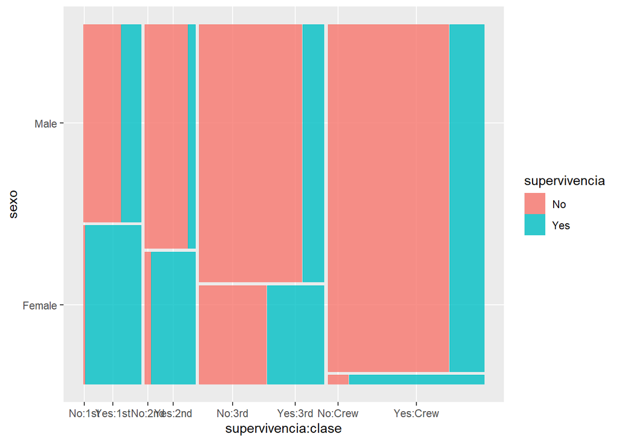

```r
mosaico3 <- ggplot(data = titanic) +
  geom_mosaic(aes(x = product(supervivencia, sexo, clase), fill = supervivencia))
mosaico3
```

# 4 Eliminar el desorden. Enfocar la atención

El gráfico anterior es muy complicado de interpretar, a no ser que se exija una fuerte atención del lector. **¿Podemos facilitarle la vida?**, porque… ¡de eso se trata en visualización!

## 4.1 El diagrama de flujo

Un diagrama de flujo es un gráfico que muestra los pasos de un proceso de una manera visual y fácil de entender, por tanto, este tipo de gráficos permitirán visualizar el flujo de los datos a través de las variables que analizamos. Véase como mejora la interpretabilidad de los datos cualitativos respecto al mosaico con tres variables variables cualitativas.

Analizamos las mismas variables cualitativas: `supervivencia`, `sexo` y `clase`, pero ahora **el gráfico es mucho más fácil de leer y, por tanto, estamos facilitando el mensaje**. En esto consiste eliminar el desorden.

**construimos el diagrama de flujo**

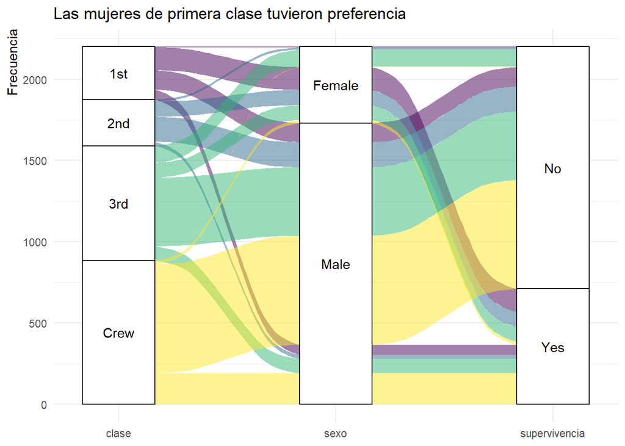

```r
tabla_titanic <- titanic |>
  group_by(clase, sexo, supervivencia) |>
  count()

flujo <- ggplot(tabla_titanic,
       aes(axis1 = clase,
           axis2 = sexo,
           axis3 = supervivencia,
           y = n)) +
  geom_alluvium(aes(fill = clase)) +
  geom_stratum() +
  geom_text(stat = "stratum",
            aes(label = after_stat(stratum))) +
  scale_x_discrete(limits = c("clase", "sexo",
                              "supervivencia"),
                   expand = c(.1, .1)) +
  scale_fill_viridis_d() +
  labs(title = "Las mujeres de primera clase tuvieron preferencia", y = "Frecuencia") +
  theme_minimal() +
  theme(legend.position = "none",
        axis.title.y = element_text(hjust = 1))
flujo
```

## 4.2 Los diagramas de árboles

Los diagramas de árbol permiten enfocar la atención y llegar a conclusiones interesantes de una forma rápida, ya que señalan las categorías más destacables en las variables. Además, combinan la visualización con la presentación de datos muy informativos…

**diagrama de árbol**

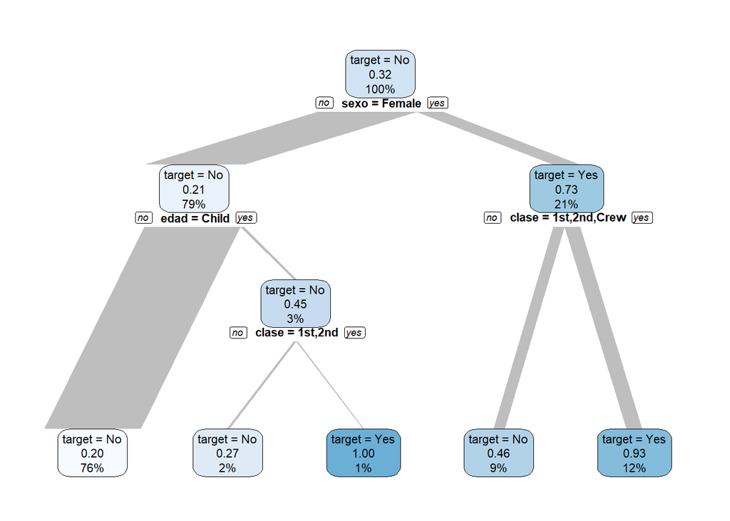

```
n= 2201

node), split, n, loss, yval, (yprob)
      * denotes terminal node

 1) root 2201 711 No (0.6769650 0.3230350)
   2) sexo=Male 1731 367 No (0.7879838 0.2120162)
     4) edad=Adult 1667 338 No (0.7972406 0.2027594) *
     5) edad=Child 64  29 No (0.5468750 0.4531250)
      10) clase=3rd 48  13 No (0.7291667 0.2708333) *
      11) clase=1st,2nd 16   0 Yes (0.0000000 1.0000000) *
   3) sexo=Female 470 126 Yes (0.2680851 0.7319149)
     6) clase=3rd 196  90 No (0.5408163 0.4591837) *
     7) clase=1st,2nd,Crew 274  20 Yes (0.0729927 0.9270073) *
```

```r
titanic_conteo |> explain_tree(target = supervivencia, n = n, out = "model")
```

Vemos que el `sexo` y la `clase` pueden dar una buena pista de quién tiene más probabilidad de salvarse:

sexo = Male: 21% supervivencia (79% de las observaciones) sexo = Female & clase = 3rd: 46% supervivencia (9%) sexo = Female & clase <> 3rd: 93% supervivencia (12%)

# 5 Una modelización muy sencilla

Como somos muy buenos colegas, y ponemos mucho interés en lo que hacemos, vamos a hacer un modelo logit sencillo, para ver si ratifica nuestros hallazgos con la fase de visualización previa.

**carga de datos de entrenamiento. Faltantes**

```r
## Cargamos los conjuntos de datos
head(titanic_train)
```

```
  PassengerId Survived Pclass
1           1        0      3
2           2        1      1
3           3        1      3
4           4        1      1
5           5        0      3
6           6        0      3
                                                 Name    Sex Age SibSp Parch
1                             Braund, Mr. Owen Harris   male  22     1     0
2 Cumings, Mrs. John Bradley (Florence Briggs Thayer) female  38     1     0
3                              Heikkinen, Miss. Laina female  26     0     0
4        Futrelle, Mrs. Jacques Heath (Lily May Peel) female  35     1     0
5                            Allen, Mr. William Henry   male  35     0     0
6                                    Moran, Mr. James   male  NA     0     0
            Ticket    Fare Cabin Embarked
1        A/5 21171  7.2500              S
2         PC 17599 71.2833   C85        C
3 STON/O2. 3101282  7.9250              S
4           113803 53.1000  C123        S
5           373450  8.0500              S
6           330877  8.4583              Q
```

**carga de datos de entrenamiento. Faltantes**

```r
sum(is.na(titanic_train))
```

```
[1] 177
```

**carga de datos de entrenamiento. Faltantes**

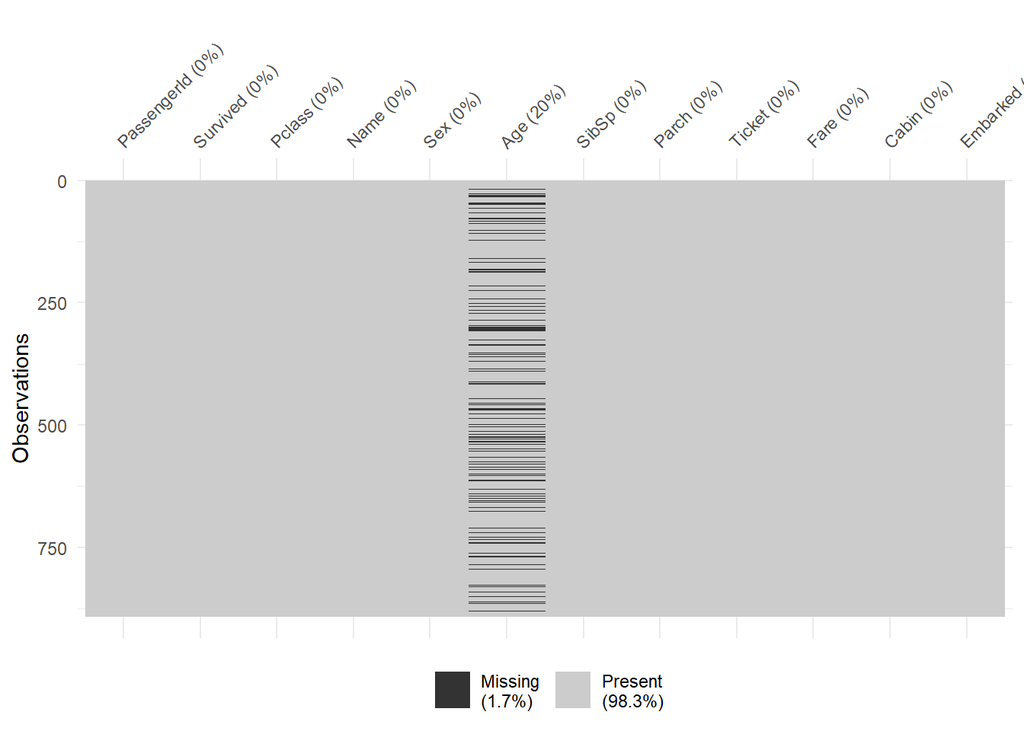

```r
vis_miss(titanic_train)
```

**Tu turno**

Completa las partes del código señaladas por `xxx` para obtener el resultado propuesto. ¿Eres capaz de recordar la función para visualizar los datos faltantes?

**Código**

```r
vis_xxxx(titanic_train)
```

**limpieza del conjunto de datos de entrenamiento**

```r
# Valores faltantes todos en la edad:
colSums(apply(titanic_train, 2, is.na))
```

```
PassengerId    Survived      Pclass        Name         Sex         Age
          0           0           0           0           0         177
      SibSp       Parch      Ticket        Fare       Cabin    Embarked
          0           0           0           0           0           0
```

**limpieza del conjunto de datos de entrenamiento**

```r
# La edad es muy importante en el modelo, por lo que solo nos quedamos con los registros completos:
titanic_data <- titanic_train[complete.cases(titanic_train),]

## Convertimos "Survived", "Pclass", "Sex" y "Embarked" a factores
for (i in c("Survived", "Pclass", "Sex", "Embarked")){
  titanic_data[,i] = as.factor(titanic_data[,i])
}

# Nos quedamos con las variables útiles
titanic_data <- titanic_data |>
  select(-c(PassengerId, Name, Ticket, Cabin))
```

**modelo**

```r
## Separando entrenamiento y test
train <- titanic_data[1:535,] # 75%
test <- titanic_data[536:714,]

## Creación del modelo
modelo <- glm(Survived ~ .,
             family = binomial(link ='logit'),
             data = train)

## Resumen del modelo
summary(modelo)
```

```
Call:
glm(formula = Survived ~ ., family = binomial(link = "logit"),
    data = train)

Coefficients:
              Estimate Std. Error z value Pr(>|z|)
(Intercept)  15.094590 535.411379   0.028 0.977509
Pclass2      -1.052932   0.389053  -2.706 0.006802 **
Pclass3      -2.325970   0.409228  -5.684 1.32e-08 ***
Sexmale      -2.556828   0.249817 -10.235  < 2e-16 ***
Age          -0.035646   0.009318  -3.825 0.000131 ***
SibSp        -0.289893   0.140889  -2.058 0.039629 *
Parch        -0.067103   0.147473  -0.455 0.649097
Fare         -0.002175   0.003412  -0.637 0.523819
EmbarkedC   -10.911734 535.411287  -0.020 0.983740
EmbarkedQ   -11.374456 535.411563  -0.021 0.983051
EmbarkedS   -11.321779 535.411276  -0.021 0.983129
---
Signif. codes:  0 '***' 0.001 '**' 0.01 '*' 0.05 '.' 0.1 ' ' 1

(Dispersion parameter for binomial family taken to be 1)

    Null deviance: 723.98  on 534  degrees of freedom
Residual deviance: 495.19  on 524  degrees of freedom
AIC: 517.19

Number of Fisher Scoring iterations: 12
```

**anova del modelo**

```r
anova(modelo, test = "Chisq")
```

```
Analysis of Deviance Table

Model: binomial, link: logit

Response: Survived

Terms added sequentially (first to last)

         Df Deviance Resid. Df Resid. Dev  Pr(>Chi)
NULL                       534     723.98
Pclass    2   61.153       532     662.83 5.259e-14 ***
Sex       1  146.844       531     515.99 < 2.2e-16 ***
Age       1   11.368       530     504.62 0.0007472 ***
SibSp     1    6.848       529     497.77 0.0088760 **
Parch     1    0.435       528     497.34 0.5095355
Fare      1    0.227       527     497.11 0.6335531
Embarked  3    1.915       524     495.19 0.5902119
---
Signif. codes:  0 '***' 0.001 '**' 0.01 '*' 0.05 '.' 0.1 ' ' 1
```

**predicciones, matriz de confusión y curva ROC**

```r
## Prediciendo el conjunto de test
resultado <- predict(modelo, newdata = test[,-1],
                     type = 'response')
resultado_factor <- as.factor(ifelse(resultado > 0.5,1,0))

## Confusion matrix and statistics
confusionMatrix(data = resultado_factor,
                reference = test$Survived)
```

```
Confusion Matrix and Statistics

          Reference
Prediction  0  1
         0 95 19
         1 13 52

               Accuracy : 0.8212
                 95% CI : (0.7571, 0.8744)
    No Information Rate : 0.6034
    P-Value [Acc > NIR] : 2.835e-10

                  Kappa : 0.621

 Mcnemar's Test P-Value : 0.3768

            Sensitivity : 0.8796
            Specificity : 0.7324
         Pos Pred Value : 0.8333
         Neg Pred Value : 0.8000
             Prevalence : 0.6034
         Detection Rate : 0.5307
   Detection Prevalence : 0.6369
      Balanced Accuracy : 0.8060

       'Positive' Class : 0
```

**predicciones, matriz de confusión y curva ROC**

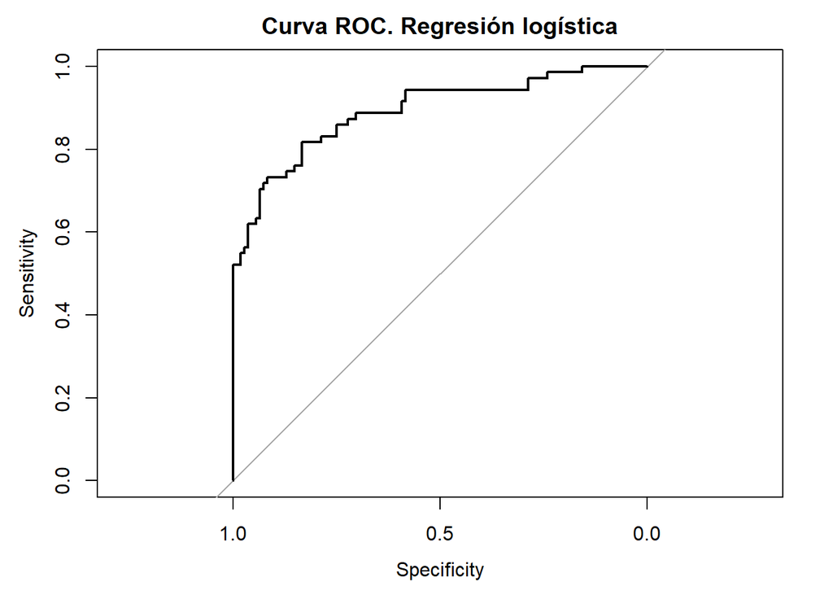

```r
## Curva ROC
auc = roc(test$Survived, resultado) # puntuación AUC
plot(auc, main ="Curva ROC. Regresión logística")
```

# 6 Contar una historia

**Cómo narrar una historia convincente con tus datos.**

Hasta ahora hemos visto el **planteamiento**, en el que proporcionamos el contexto: un colega de departamento nos ha pedido ayuda. Si es científico, como nosotros, podemos utilizar todo nuestro arsenal gráfico sin problemas. Como quiere hacer predicción, está interesado en ver la influencia de las variables en la `supervivencia`.

El análisis exploratorio nos introduce de lleno en la **trama**, donde descubrimos que la `edad`, el `sexo` y la `clase` tienen influencia en la variable `supervivencia`.

## 6.1 Para pensar:

Si se hundiera hoy en día el Titanic, ¿habría cambiado la influencia de alguna variable en el modelo? ¿Tendríamos una visualización más confusa en el gráfico de flujo?